# Assignment 3

Nathaniel Fleming

2023-04-03

Data Background:

This data contains information on on each pokemon from the first generation Kanto Region to the 6th generation Kalos Region Pokemon X and Y. The data contains 721 unique pokemon with 800 entries for pokemon. Some of these entries include the same pokemon but with a region/generation specific entry, these values will not be included for complexities sake.

The fields include:

X: ID for each pokemon

Name: Name of each pokemon

Type 1: Each pokemon has a type, this determines weakness/resistance to attacks

Type 2: Some pokemon are dual type and have 2

Total: sum of all stats that come after this, a general guide to how strong a pokemon is

HP: hit points, or health, defines how much damage a pokemon can withstand before fainting

Attack: the base modifier for normal attacks (eg. Scratch, Punch)

Defense: the base damage resistance against normal attacks

SP Atk: special attack, the base modifier for special attacks (e.g. fire blast, bubble beam)

SP Def: the base damage resistance against special attacks

Speed: determines which pokemon attacks first each round.

Legendary: These pokemon can only be caught once and usually have higher stats

Through this dataset I want to observe what features have an impact on the total stats a pokemon has. through this I will be conducting analysis on several different stats and types.

Import the dataset, I chose pokemon to be the dataset to analyze as it is near and dear to my heart. The first step is to read the data.

```r
pokemonData<- read.csv("C:/Users/Nathaniel Fleming/Desktop/Mohawk/Coding/Assignment 3/Pokemon/Pokemon.csv")
```

I imported the correct colour pallete for the pokemon types so that visualization is easier and more accurate to the colour of the types that are in pokemon.

```r
# Define custom color palette
pokemon_colors <- c("Fire" = "#EE8130", "Water" = "#6390F0", "Grass" = "#7AC74C", "Electric" = "#F7D02C",
                    "Ice" = "#96D9D6", "Fighting" = "#C22E28", "Poison" = "#A33EA1", "Ground" = "#E2BF65",
                    "Flying" = "#A98FF3", "Psychic" = "#F95587", "Bug" = "#A6B91A", "Rock" = "#B6A136",
                    "Ghost" = "#735797", "Dragon" = "#6F35FC", "Dark" = "#705746", "Steel" = "#B7B7CE",
                    "Fairy" = "#D685AD")
```

Explore the dataset and get to know the variables and datatypes associated with the csv

```r
View(pokemonData)
```

Checking the structure of the data

```r
str(pokemonData)
```

```
## 'data.frame':    800 obs. of  13 variables:
##  $ X.        : int  1 2 3 3 4 5 6 6 6 7 ...
##  $ Name      : chr  "Bulbasaur" "Ivysaur" "Venusaur" "VenusaurMega Venusaur" ...
##  $ Type.1    : chr  "Grass" "Grass" "Grass" "Grass" ...
##  $ Type.2    : chr  "Poison" "Poison" "Poison" "Poison" ...
##  $ Total     : int  318 405 525 625 309 405 534 634 634 314 ...
##  $ HP        : int  45 60 80 80 39 58 78 78 78 44 ...
##  $ Attack    : int  49 62 82 100 52 64 84 130 104 48 ...
##  $ Defense   : int  49 63 83 123 43 58 78 111 78 65 ...
##  $ Sp..Atk   : int  65 80 100 122 60 80 109 130 159 50 ...
##  $ Sp..Def   : int  65 80 100 120 50 65 85 85 115 64 ...
##  $ Speed     : int  45 60 80 80 65 80 100 100 100 43 ...
##  $ Generation: int  1 1 1 1 1 1 1 1 1 1 ...
##  $ Legendary : chr  "False" "False" "False" "False" ...
```

Checking the summary statistics of the dataset

```r
summary(pokemonData)
```

```
##        X.            Name              Type.1             Type.2
##  Min.   :  1.0   Length:800         Length:800         Length:800
##  1st Qu.:184.8   Class :character   Class :character   Class :character
##  Median :364.5   Mode  :character   Mode  :character   Mode  :character
##  Mean   :362.8
##  3rd Qu.:539.2
##  Max.   :721.0
##      Total             HP             Attack       Defense
##  Min.   :180.0   Min.   :  1.00   Min.   :  5   Min.   :  5.00
##  1st Qu.:330.0   1st Qu.: 50.00   1st Qu.: 55   1st Qu.: 50.00
##  Median :450.0   Median : 65.00   Median : 75   Median : 70.00
##  Mean   :435.1   Mean   : 69.26   Mean   : 79   Mean   : 73.84
##  3rd Qu.:515.0   3rd Qu.: 80.00   3rd Qu.:100   3rd Qu.: 90.00
##  Max.   :780.0   Max.   :255.00   Max.   :190   Max.   :230.00
##     Sp..Atk          Sp..Def          Speed          Generation
##  Min.   : 10.00   Min.   : 20.0   Min.   :  5.00   Min.   :1.000
##  1st Qu.: 49.75   1st Qu.: 50.0   1st Qu.: 45.00   1st Qu.:2.000
##  Median : 65.00   Median : 70.0   Median : 65.00   Median :3.000
##  Mean   : 72.82   Mean   : 71.9   Mean   : 68.28   Mean   :3.324
##  3rd Qu.: 95.00   3rd Qu.: 90.0   3rd Qu.: 90.00   3rd Qu.:5.000
##  Max.   :194.00   Max.   :230.0   Max.   :180.00   Max.   :6.000
##   Legendary
##  Length:800
##  Class :character
##  Mode  :character
##
##
##
```

```r
head(pokemonData)
```

|  | X. | Name | Type.1 | Type.2 | Total | HP | Attack | Defense | Sp..Atk | Sp..Def | Speed | Generation | Legendary |
| --- | --- | --- | --- | --- | --- | --- | --- | --- | --- | --- | --- | --- | --- |
| 1 | 1 | Bulbasaur | Grass | Poison | 318 | 45 | 49 | 49 | 65 | 65 | 45 | 1 | False |
| 2 | 2 | Ivysaur | Grass | Poison | 405 | 60 | 62 | 63 | 80 | 80 | 60 | 1 | False |
| 3 | 3 | Venusaur | Grass | Poison | 525 | 80 | 82 | 83 | 100 | 100 | 80 | 1 | False |
| 4 | 3 | VenusaurMega Venusaur | Grass | Poison | 625 | 80 | 100 | 123 | 122 | 120 | 80 | 1 | False |
| 5 | 4 | Charmander | Fire |  | 309 | 39 | 52 | 43 | 60 | 50 | 65 | 1 | False |
| 6 | 5 | Charmeleon | Fire |  | 405 | 58 | 64 | 58 | 80 | 65 | 80 | 1 | False |

```r
tail(pokemonData)
```

|  | X. | Name | Type.1 | Type.2 | Total | HP | Attack | Defense | Sp..Atk | Sp..Def | Speed | Generation | Legendary |
| --- | --- | --- | --- | --- | --- | --- | --- | --- | --- | --- | --- | --- | --- |
| 795 | 718 | Zygarde50% Forme | Dragon | Ground | 600 | 108 | 100 | 121 | 81 | 95 | 95 | 6 | True |
| 796 | 719 | Diancie | Rock | Fairy | 600 | 50 | 100 | 150 | 100 | 150 | 50 | 6 | True |
| 797 | 719 | DiancieMega Diancie | Rock | Fairy | 700 | 50 | 160 | 110 | 160 | 110 | 110 | 6 | True |
| 798 | 720 | HoopaHoopa Confined | Psychic | Ghost | 600 | 80 | 110 | 60 | 150 | 130 | 70 | 6 | True |
| 799 | 720 | HoopaHoopa Unbound | Psychic | Dark | 680 | 80 | 160 | 60 | 170 | 130 | 80 | 6 | True |
| 800 | 721 | Volcanion | Fire | Water | 600 | 80 | 110 | 120 | 130 | 90 | 70 | 6 | True |

Cleaning the Dataset

```r
dupe_rows<- duplicated(pokemonData$X.)
pokemonNoDupes<- subset(pokemonData,!dupe_rows)
summary(pokemonNoDupes)
```

```
##        X.          Name              Type.1             Type.2
##  Min.   :  1   Length:721         Length:721         Length:721
##  1st Qu.:181   Class :character   Class :character   Class :character
##  Median :361   Mode  :character   Mode  :character   Mode  :character
##  Mean   :361
##  3rd Qu.:541
##  Max.   :721
##      Total             HP             Attack          Defense
##  Min.   :180.0   Min.   :  1.00   Min.   :  5.00   Min.   :  5.0
##  1st Qu.:320.0   1st Qu.: 50.00   1st Qu.: 54.00   1st Qu.: 50.0
##  Median :424.0   Median : 65.00   Median : 75.00   Median : 65.0
##  Mean   :417.9   Mean   : 68.38   Mean   : 75.12   Mean   : 70.7
##  3rd Qu.:499.0   3rd Qu.: 80.00   3rd Qu.: 95.00   3rd Qu.: 85.0
##  Max.   :720.0   Max.   :255.00   Max.   :165.00   Max.   :230.0
##     Sp..Atk          Sp..Def           Speed          Generation
##  Min.   : 10.00   Min.   : 20.00   Min.   :  5.00   Min.   :1.000
##  1st Qu.: 45.00   1st Qu.: 50.00   1st Qu.: 45.00   1st Qu.:2.000
##  Median : 65.00   Median : 65.00   Median : 65.00   Median :3.000
##  Mean   : 68.85   Mean   : 69.18   Mean   : 65.71   Mean   :3.323
##  3rd Qu.: 90.00   3rd Qu.: 85.00   3rd Qu.: 85.00   3rd Qu.:5.000
##  Max.   :154.00   Max.   :230.00   Max.   :160.00   Max.   :6.000
##   Legendary
##  Length:721
##  Class :character
##  Mode  :character
##
##
##
```

Check for outliers

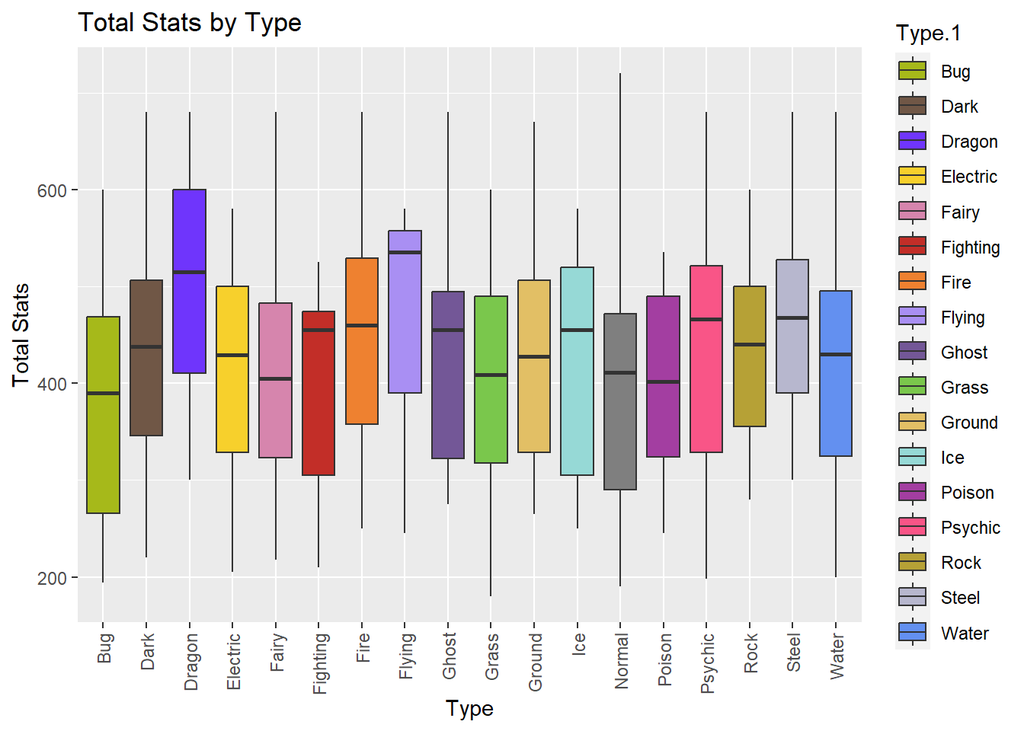

```r
# Create a box plot of Total stats by Type
boxplot_type_total <- ggplot(pokemonNoDupes, aes(x = Type.1, y = Total, fill = Type.1)) +
  geom_boxplot() +
  labs(x = "Type", y = "Total Stats", title = "Total Stats by Type")+
  theme(axis.text.x = element_text(angle = 90, vjust = 0.5, hjust=1))

# Apply custom color palette
boxplot_type_total + scale_fill_manual(values = pokemon_colors)
```

I wanted to compare pokemon that have more than one type to those with only one so I subset the data into multitype and single type pokemon. This way we can compare pokemon that have more than one type versus the pokemon with one type.

```r
# Filter out blank values that are just spaces in the Type.2 column
multi_type_pokemon <- pokemonNoDupes[nchar(trimws(pokemonNoDupes$Type.2)) > 0, ]

# Filter out blank values in the Type.2 column
multi_type_pokemon
```

|  | X. | Name | Type.1 | Type.2 | Total | HP | Attack | Defense | Sp..Atk | Sp..Def | Speed | Generation | Legendary |
| --- | --- | --- | --- | --- | --- | --- | --- | --- | --- | --- | --- | --- | --- |
| 1 | 1 | Bulbasaur | Grass | Poison | 318 | 45 | 49 | 49 | 65 | 65 | 45 | 1 | False |
| 2 | 2 | Ivysaur | Grass | Poison | 405 | 60 | 62 | 63 | 80 | 80 | 60 | 1 | False |
| 3 | 3 | Venusaur | Grass | Poison | 525 | 80 | 82 | 83 | 100 | 100 | 80 | 1 | False |
| 7 | 6 | Charizard | Fire | Flying | 534 | 78 | 84 | 78 | 109 | 85 | 100 | 1 | False |
| 16 | 12 | Butterfree | Bug | Flying | 395 | 60 | 45 | 50 | 90 | 80 | 70 | 1 | False |
| 17 | 13 | Weedle | Bug | Poison | 195 | 40 | 35 | 30 | 20 | 20 | 50 | 1 | False |
| 18 | 14 | Kakuna | Bug | Poison | 205 | 45 | 25 | 50 | 25 | 25 | 35 | 1 | False |
| 19 | 15 | Beedrill | Bug | Poison | 395 | 65 | 90 | 40 | 45 | 80 | 75 | 1 | False |
| 21 | 16 | Pidgey | Normal | Flying | 251 | 40 | 45 | 40 | 35 | 35 | 56 | 1 | False |
| 22 | 17 | Pidgeotto | Normal | Flying | 349 | 63 | 60 | 55 | 50 | 50 | 71 | 1 | False |

[output cut: 340 more lines]

```r
#Single Type pokemon
# Filter for empty values in the Type.2 column
Single_Type_Pokemon <- pokemonNoDupes[is.na(pokemonNoDupes$Type.2) | nchar(trimws(pokemonNoDupes$Type.2)) == 0, ]
Single_Type_Pokemon
```

|  | X. | Name | Type.1 | Type.2 | Total | HP | Attack | Defense | Sp..Atk | Sp..Def | Speed | Generation | Legendary |
| --- | --- | --- | --- | --- | --- | --- | --- | --- | --- | --- | --- | --- | --- |
| 5 | 4 | Charmander | Fire |  | 309 | 39 | 52 | 43 | 60 | 50 | 65 | 1 | False |
| 6 | 5 | Charmeleon | Fire |  | 405 | 58 | 64 | 58 | 80 | 65 | 80 | 1 | False |
| 10 | 7 | Squirtle | Water |  | 314 | 44 | 48 | 65 | 50 | 64 | 43 | 1 | False |
| 11 | 8 | Wartortle | Water |  | 405 | 59 | 63 | 80 | 65 | 80 | 58 | 1 | False |
| 12 | 9 | Blastoise | Water |  | 530 | 79 | 83 | 100 | 85 | 105 | 78 | 1 | False |
| 14 | 10 | Caterpie | Bug |  | 195 | 45 | 30 | 35 | 20 | 20 | 45 | 1 | False |
| 15 | 11 | Metapod | Bug |  | 205 | 50 | 20 | 55 | 25 | 25 | 30 | 1 | False |
| 25 | 19 | Rattata | Normal |  | 253 | 30 | 56 | 35 | 25 | 35 | 72 | 1 | False |
| 26 | 20 | Raticate | Normal |  | 413 | 55 | 81 | 60 | 50 | 70 | 97 | 1 | False |
| 29 | 23 | Ekans | Poison |  | 288 | 35 | 60 | 44 | 40 | 54 | 55 | 1 | False |

[output cut: 361 more lines]

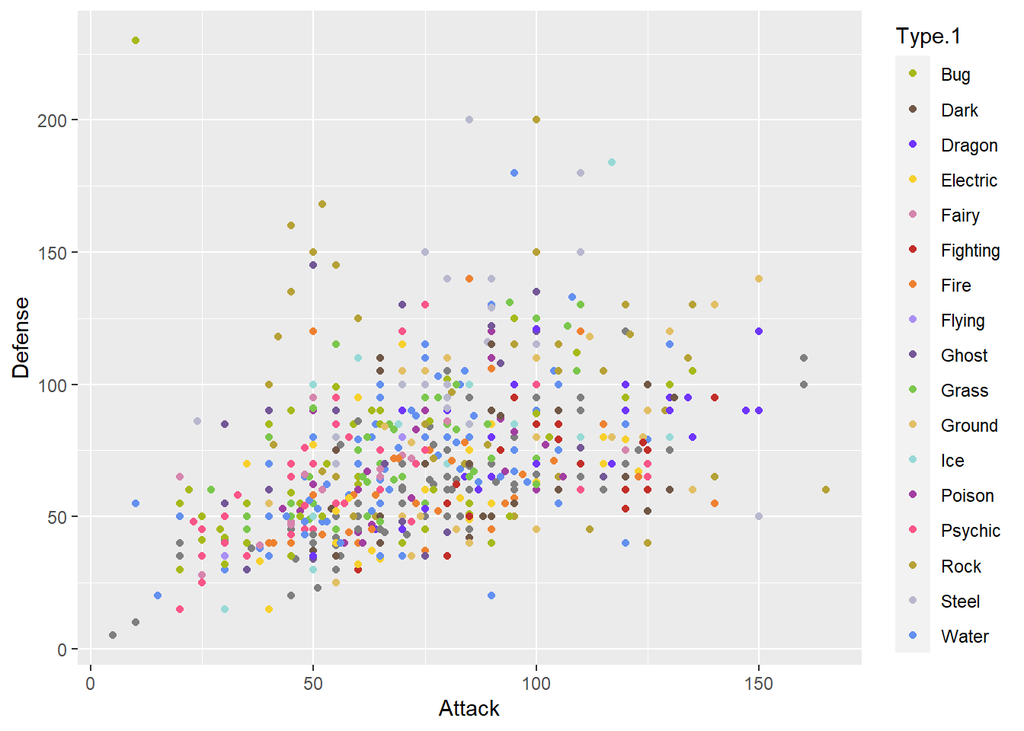

```r
# Create scatterplot with custom colors
ggplot(pokemonNoDupes, aes(x = Attack, y = Defense, color = Type.1)) +
  geom_point() +
  scale_color_manual(values = pokemon_colors)
```

Exploration into the speeds

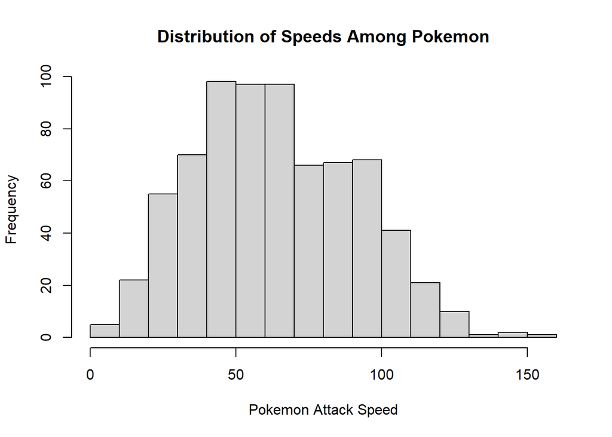

```r
hist(pokemonNoDupes$Speed, breaks = 20, xlab = "Pokemon Attack Speed", main = "Distribution of Speeds Among Pokemon", col = )
```

```r
legendary_pokemon <- subset(pokemonNoDupes,Legendary == 'True' )
legendary_pokemon
```

|  | X. | Name | Type.1 | Type.2 | Total | HP | Attack | Defense | Sp..Atk | Sp..Def | Speed | Generation | Legendary |
| --- | --- | --- | --- | --- | --- | --- | --- | --- | --- | --- | --- | --- | --- |
| 157 | 144 | Articuno | Ice | Flying | 580 | 90 | 85 | 100 | 95 | 125 | 85 | 1 | True |
| 158 | 145 | Zapdos | Electric | Flying | 580 | 90 | 90 | 85 | 125 | 90 | 100 | 1 | True |
| 159 | 146 | Moltres | Fire | Flying | 580 | 90 | 100 | 90 | 125 | 85 | 90 | 1 | True |
| 163 | 150 | Mewtwo | Psychic |  | 680 | 106 | 110 | 90 | 154 | 90 | 130 | 1 | True |
| 263 | 243 | Raikou | Electric |  | 580 | 90 | 85 | 75 | 115 | 100 | 115 | 2 | True |
| 264 | 244 | Entei | Fire |  | 580 | 115 | 115 | 85 | 90 | 75 | 100 | 2 | True |
| 265 | 245 | Suicune | Water |  | 580 | 100 | 75 | 115 | 90 | 115 | 85 | 2 | True |
| 270 | 249 | Lugia | Psychic | Flying | 680 | 106 | 90 | 130 | 90 | 154 | 110 | 2 | True |
| 271 | 250 | Ho-oh | Fire | Flying | 680 | 106 | 130 | 90 | 110 | 154 | 90 | 2 | True |
| 415 | 377 | Regirock | Rock |  | 580 | 80 | 100 | 200 | 50 | 100 | 50 | 3 | True |

[output cut: 36 more lines]

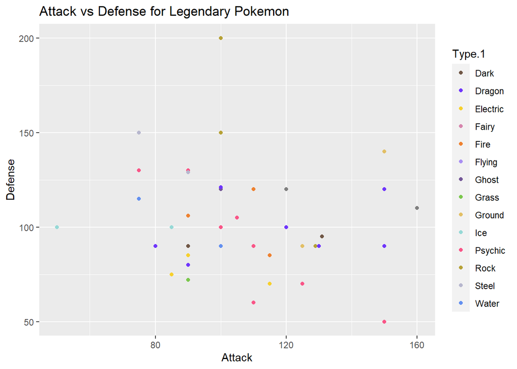

```r
ggplot(legendary_pokemon, aes(x = Attack, y = Defense, color = Type.1)) +
  geom_point() +
  labs(title = "Attack vs Defense for Legendary Pokemon",
       x = "Attack", y = "Defense") +
   scale_color_manual(values = pokemon_colors)
```

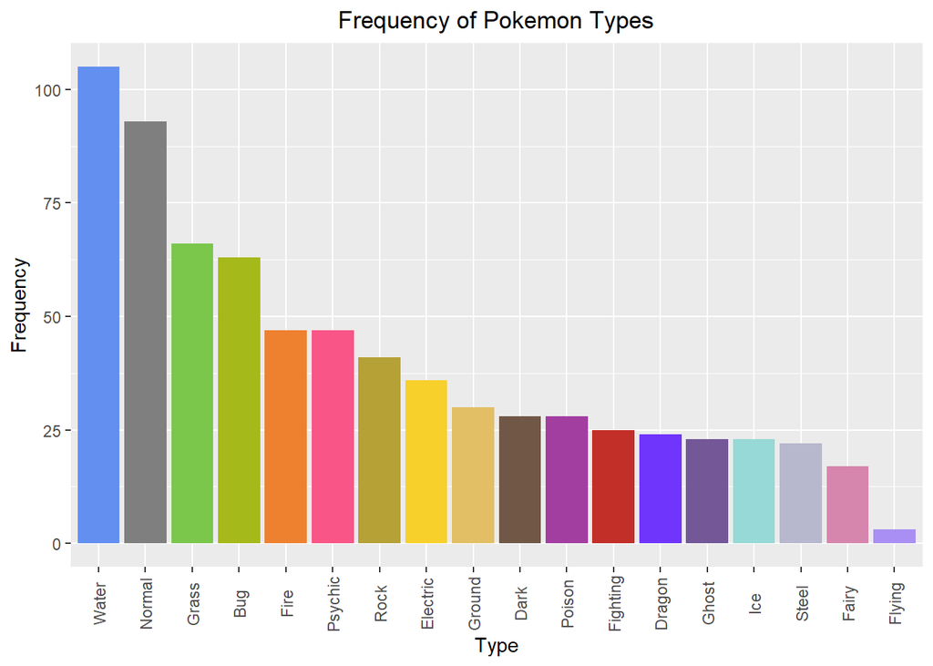

```r
# calculate frequency of each type
type_freq <- table(pokemonNoDupes$Type.1)

# convert table to data frame and sort by frequency
type_freq_df <- data.frame(Type = names(type_freq), Freq = as.vector(type_freq))
type_freq_df <- type_freq_df[order(type_freq_df$Freq, decreasing = TRUE), ]

# create bar plot
ggplot(type_freq_df, aes(x = reorder(Type, -Freq), y = Freq, fill = Type)) +
  geom_bar(stat = "identity") +
  scale_fill_manual(values = pokemon_colors) +
  xlab("Type") +
  ylab("Frequency") +
  ggtitle("Frequency of Pokemon Types") +
  theme(plot.title = element_text(hjust = 0.5))+
  theme(axis.text.x = element_text(angle = 90, vjust = 0.5),legend.position = 'none')
```